# Homework 3

Author

Hanna Fei

## **Text Mining**

### Question 1

1. (15 points) How many abstracts are associated with each search term? Tokenize the abstracts and count the number of each token. Do you see anything interesting? What are the 5 most common tokens for each search term?

```r
# count number of abstracts in each search term
pubmed %>%
  count(term)
```

```
             term   n
1           covid 981
2 cystic fibrosis 376
3      meningitis 317
4    preeclampsia 780
5 prostate cancer 787
```

```r
# tokenize abstracts
tokens <- pubmed %>%
  unnest_tokens(token, abstract)

# count number of each token
pubmed_count <- tokens %>%
  count(token, sort = TRUE)

head(pubmed_count, 15)
```

```
      token     n
1       the 28126
2        of 24760
3       and 19993
4        in 14653
5        to 10920
6         a  8245
7      with  8038
8     covid  7275
9        19  7080
10       is  5649
11      for  5492
12 patients  4674
13   cancer  3999
14 prostate  3832
15      was  3315
```

```r
# 5 most common tokens for each term
pubmed_terms <- tokens %>%
  group_by(term) %>%
  count(token) %>%
  top_n(5, n)

pubmed_terms
```

```
# A tibble: 25 × 3
# Groups:   term [5]
   term            token        n
   <chr>           <chr>    <int>
 1 covid           19        7035
 2 covid           and       6861
 3 covid           covid     7275
 4 covid           of        7668
 5 covid           the       9741
 6 cystic fibrosis and       1777
 7 cystic fibrosis in        1497
 8 cystic fibrosis of        2304
 9 cystic fibrosis the       2677
10 cystic fibrosis to        1011
11 meningitis      a          830
12 meningitis      and       1683
13 meningitis      in        1322
14 meningitis      of        2269
15 meningitis      the       2489
16 preeclampsia    and       5255
17 preeclampsia    in        3869
18 preeclampsia    of        6837
19 preeclampsia    the       7119
20 preeclampsia    to        2651
21 prostate cancer and       4417
22 prostate cancer cancer    3840
23 prostate cancer of        5682
24 prostate cancer prostate  3832
25 prostate cancer the       6100
```

Search terms ‘covid’, ‘prostate cancer’, and ‘preeclampsia’ have the most abstracts. When we look at the counts of each token, the top 15 include covid, 19, cancer, prostate, and patients among other stop words. This makes sense because there are more abstracts related to those terms. It is important to group by search term when analyzing the tokens because certain search terms are more representative in this data, which can affect sentiment analysis if the sentiments are different among different search terms.

### Question 2

2. (15 points) Does removing stop words change what tokens appear as the most frequent? What are the 5 most common tokens for each search term after removing stop words?

```r
pubmed_stop <- tokens %>%
  # remove stop words
  anti_join(stop_words, by = c("token" = "word")) %>%
  # 5 most common tokens for each term
  group_by(term) %>%
  count(token) %>%
  top_n(5,n)

pubmed_stop
```

```
# A tibble: 25 × 3
# Groups:   term [5]
   term            token            n
   <chr>           <chr>        <int>
 1 covid           19            7035
 2 covid           covid         7275
 3 covid           disease        943
 4 covid           pandemic       800
 5 covid           patients      2293
 6 cystic fibrosis cf             625
 7 cystic fibrosis cystic         862
 8 cystic fibrosis disease        400
 9 cystic fibrosis fibrosis       867
10 cystic fibrosis patients       586
11 meningitis      clinical       187
12 meningitis      csf            206
13 meningitis      meningeal      219
14 meningitis      meningitis     429
15 meningitis      patients       446
16 preeclampsia    eclampsia     2005
17 preeclampsia    pre           2038
18 preeclampsia    preeclampsia  1863
19 preeclampsia    pregnancy      969
20 preeclampsia    women         1196
21 prostate cancer cancer        3840
22 prostate cancer disease        652
23 prostate cancer patients       934
24 prostate cancer prostate      3832
25 prostate cancer treatment      926
```

After removing stop words, the tokens that appear as most frequent are much more related to their corresponding search term.

### Question 3

3. (15 points) Tokenize the abstracts into bigrams. Find the 10 most common bigrams and visualize them.

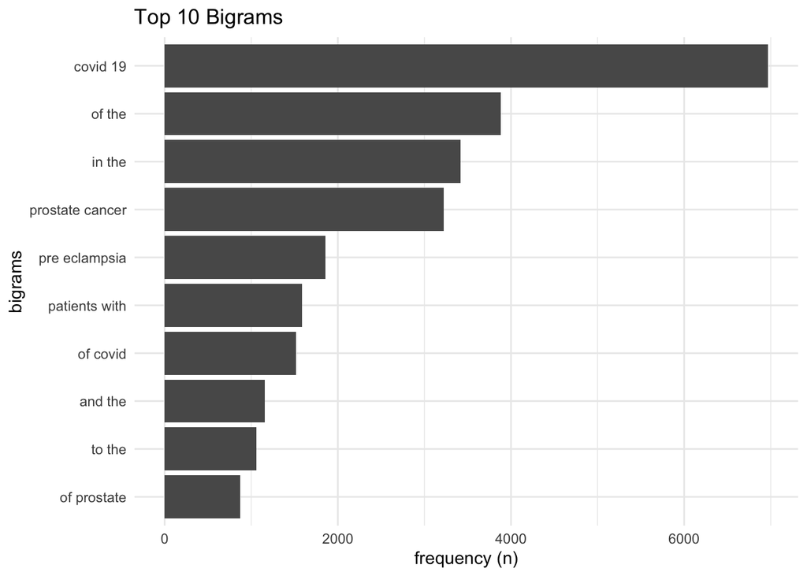

```r
# tokenize into bigrams
bigrams <- pubmed %>%
  unnest_ngrams(ngram, abstract, n = 2)

# visualize 10 most common bigrams
top_bigrams <- bigrams %>%
  count(ngram, sort = TRUE) %>%
  top_n(10, n) %>%
  ggplot(aes(n, fct_reorder(ngram, n))) +
  geom_col() +
  labs(title = "Top 10 Bigrams", y = "bigrams", x = "frequency (n)") +
  theme_minimal()

top_bigrams
```

Some of the top 10 bigrams include covid 19, prostate cancer, and pre eclampsia which are often used together as one phrase.

### Question 4

4. (15 points) Calculate the TF-IDF value for each word-search term combination (here you want the search term to be the “document”). What are the 5 tokens from each search term with the highest TF-IDF value? How are the results different from the answers you got in Question 1?

```r
tf_idf <- pubmed %>%
  unnest_tokens(token, abstract) %>%
  count(term, token) %>%
  bind_tf_idf(token, term, n) %>%
  group_by(term) %>%
  top_n(5, tf_idf)

tf_idf
```

```
# A tibble: 25 × 6
# Groups:   term [5]
   term            token               n      tf   idf  tf_idf
   <chr>           <chr>           <int>   <dbl> <dbl>   <dbl>
 1 covid           coronavirus       647 0.00330 1.61  0.00531
 2 covid           cov               334 0.00170 1.61  0.00274
 3 covid           covid            7275 0.0371  1.61  0.0597
 4 covid           pandemic          800 0.00408 1.61  0.00657
 5 covid           sars              372 0.00190 1.61  0.00305
 6 cystic fibrosis cf                625 0.0127  0.916 0.0117
 7 cystic fibrosis cftr               86 0.00175 1.61  0.00282
 8 cystic fibrosis cystic            862 0.0175  0.511 0.00896
 9 cystic fibrosis fibrosis          867 0.0176  0.511 0.00901
10 cystic fibrosis sweat              83 0.00169 1.61  0.00272
11 meningitis      csf               206 0.00441 0.916 0.00405
12 meningitis      meningeal         219 0.00469 1.61  0.00755
13 meningitis      meninges          106 0.00227 1.61  0.00366
14 meningitis      meningitis        429 0.00919 1.61  0.0148
15 meningitis      pachymeningitis   149 0.00319 1.61  0.00514
16 preeclampsia    eclampsia        2005 0.0143  1.61  0.0230
17 preeclampsia    gestational       191 0.00136 1.61  0.00219
18 preeclampsia    maternal          797 0.00568 0.511 0.00290
19 preeclampsia    preeclampsia     1863 0.0133  1.61  0.0214
20 preeclampsia    pregnancy         969 0.00690 0.511 0.00353
21 prostate cancer androgen          305 0.00248 1.61  0.00400
22 prostate cancer castration        148 0.00120 1.61  0.00194
23 prostate cancer prostate         3832 0.0312  1.61  0.0502
24 prostate cancer prostatectomy     215 0.00175 1.61  0.00282
25 prostate cancer psa               282 0.00230 1.61  0.00369
```

These token results are even more specific to each search term compared to question 1 and 2, because the words with the highest tf-idf are words that are most common in each term but also are unique to those terms.

## **Sentiment Analysis**

### Question 5

5. (20 points) Perform a sentiment analysis using the NRC lexicon. What is the most common sentiment for each search term? What if you remove `"positive"` and `"negative"` from the list?

```r
sentiments <- pubmed %>%
  unnest_tokens(word, abstract) %>%
  inner_join(get_sentiments("nrc"))

# top sentiment for each search term
term_sentiments <- sentiments %>%
  group_by(term) %>%
  count(sentiment) %>%
  top_n(1, n)

term_sentiments
```

```
# A tibble: 5 × 3
# Groups:   term [5]
  term            sentiment     n
  <chr>           <chr>     <int>
1 covid           positive   9874
2 cystic fibrosis positive   2747
3 meningitis      negative   2109
4 preeclampsia    positive   8014
5 prostate cancer negative   8918
```

```r
# removing "positive" and "negative"
nrc_fun <- get_sentiments("nrc")
nrc_fun <- nrc_fun[!nrc_fun$sentiment %in% c("positive", "negative"), ]

term_sentiments_rm <- pubmed %>%
  unnest_tokens(word, abstract) %>%
  inner_join(nrc_fun) %>%
  group_by(term) %>%
  count(sentiment) %>%
  top_n(1, n)

term_sentiments_rm
```

```
# A tibble: 5 × 3
# Groups:   term [5]
  term            sentiment        n
  <chr>           <chr>        <int>
1 covid           fear          7730
2 cystic fibrosis disgust       1714
3 meningitis      fear          1510
4 preeclampsia    anticipation  4780
5 prostate cancer fear          8118
```

Using the NRC lexicon, the most common sentiment for each search term is either “positive” or “negative.” After removing “positive” and “negative,” the sentiments for each search term become more interesting, with sentiments including fear, disgust, and anticipation.

### Question 6

6. (20 points) Now perform a sentiment analysis using the AFINN lexicon to get an average positivity score for each abstract (hint: you may want to create a variable that indexes, or counts, the abstracts). Create a visualization that shows these scores grouped by search term. Are any search terms noticeably different from the others?

```r
# create variable to index abstracts
pubmed <- pubmed %>%
  mutate(id = row_number())

# get afinn scores
score_abstracts <- pubmed %>%
  unnest_tokens(word, abstract) %>%
  inner_join(get_sentiments("afinn"))

# average afinn score for each abstract
avg_per_abstract <- score_abstracts %>%
  group_by(id) %>%
  summarize(sentiment = mean(value))

head(avg_per_abstract)
```

```
# A tibble: 6 × 2
     id sentiment
  <int>     <dbl>
1     1    -1.13
2     2    -2
3     3     0.214
4     4    -0.8
5     5    -1.67
6     6    -0.143
```

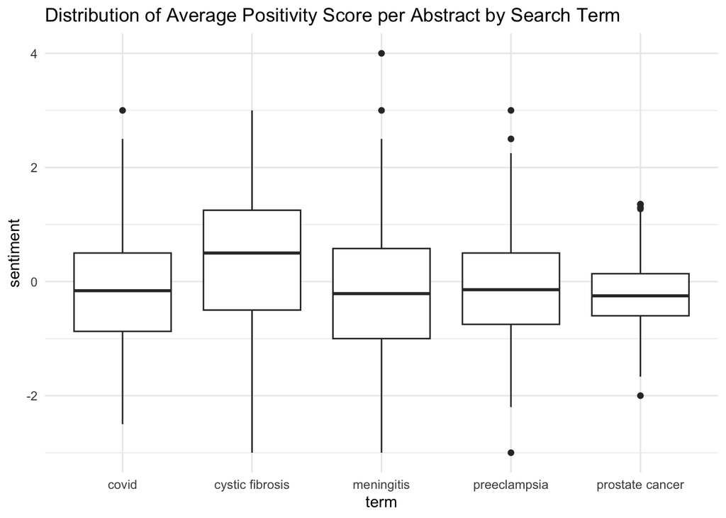

```r
# visualize scores grouped by search term
avg_by_term <- score_abstracts %>%
  group_by(id, term) %>%
  summarize(sentiment = mean(value)) %>%
  ungroup()

ggplot(avg_by_term, aes(x = term, y = sentiment)) +
  geom_boxplot() +
  labs(title = "Distribution of Average Positivity Score per Abstract by Search Term") +
  theme_minimal()
```

All search terms have a negative median of average sentiment per abstract except for cystic fibrosis, which has a very positive median in comparison to the others.